# Threat Modeling Report

Created on 23.12.2021 00:23:43

**Threat Model Name:**

**Owner:**

**Reviewer:**

**Contributors:**

**Description:**

**Assumptions:**

**External Dependencies:**

### Threat Model Summary:

| Not Started | 43 |
| --- | --- |
| Not Applicable | 0 |
| Needs Investigation | 0 |
| Mitigation Implemented | 0 |
| Total | 43 |
| Total Migrated | 0 |

## Diagram: AWS Example

[figure not shown]

### AWS Example Diagram Summary:

| Not Started | 43 |
| --- | --- |
| Not Applicable | 0 |
| Needs Investigation | 0 |
| Mitigation Implemented | 0 |
| Total | 43 |
| Total Migrated | 0 |

### Interaction: GET Secret

[figure not shown]

#### 1. Amazon CloudFront Field-Level Encryption [State: Not Started] [Priority: High]

[output not shown]

#### 2. AWS Trusted Advisor usage [State: Not Started] [Priority: High]

| **Category:** | Network Boundary |
| --- | --- |
| **Description:** | AWS Trusted Advisor is a tool, that allows to evaluate AWS account security (such as SG unrestricted ports and access, IAM policies, MFA usage, etc ) and optimization best practices |
| **Justification:** | Security Requirement |
| **Action Items:** | 1. Ensure that AWS Trusted Advisor is used and its report reviewed on a regular basis |
| **Comments:** |  |

#### 3. AWS WAF [State: Not Started] [Priority: Critical]

[output not shown]

#### 4. AWS Shield usage [State: Not Started] [Priority: High]

[output not shown]

### Interaction: GET Secret (encrypted)

[figure not shown]

#### 5. Security best practices in Amazon API Gateway [State: Not Started] [Priority: High]

[output not shown]

#### 6. Amazon CloudFront Field-Level Encryption [State: Not Started] [Priority: High]

[output not shown]

### Interaction: GET Secret (encrypted)

[figure not shown]

#### 7. AWS Separation of Lambda Concerns [State: Not Started] [Priority: High]

[output not shown]

#### 8. AWS Lambda Low Privilege principle [State: Not Started] [Priority: High]

[output not shown]

#### 9. Security best practices in Amazon API Gateway [State: Not Started] [Priority: High]

[output not shown]

#### 10. Encryption in Transit for GET Secret (encrypted) within VPC [State: Not Started] [Priority: High]

| **Category:** | Data Flows |
| --- | --- |
| **Description:** | TLS should be configured for GET Secret (encrypted) to prevent attack related with unauthorized data access within VPC |
| **Justification:** | Security Requirement |
| **Action Items:** | 1. Ensure Strong TLS is configured (TLS 1.2, 1.3) for Encrypted Phone number |
| **Comments:** |  |

#### 11. AWS Lambda Enable Dead Letter Queue for Lambda Functions [State: Not Started] [Priority: Low]

| **Category:** | Compute |
| --- | --- |
| **Description:** | Ensure there is a Dead Letter Queue configured for each Lambda function available in your AWS account |
| **Justification:** | <no mitigation provided> |
| **Action Items:** | https://www.trendmicro.com/cloudoneconformity/knowledge-base/aws/Lambda/enable-dead-letter-queue.html |
| **Comments:** |  |

#### 12. Using An IAM Role For More Than One Lambda Function [State: Not Started] [Priority: High]

[output not shown]

#### 13. VPC Access for AWS Lambda Functions [State: Not Started] [Priority: Medium]

[output not shown]

### Interaction: GET Secret (encrypted)

[figure not shown]

#### 14. Encryption in Transit for GET Secret (encrypted) within VPC [State: Not Started] [Priority: High]

| **Category:** | Data Flows |
| --- | --- |
| **Description:** | TLS should be configured for GET Secret (encrypted) to prevent attack related with unauthorized data access within VPC |
| **Justification:** | Security Requirement |
| **Action Items:** | 1. Ensure Strong TLS is configured (TLS 1.2, 1.3) for Encrypted Phone number |
| **Comments:** |  |

#### 15. AWS Separation of Lambda Concerns [State: Not Started] [Priority: High]

[output not shown]

#### 16. AWS Lambda Low Privilege principle [State: Not Started] [Priority: High]

[output not shown]

#### 17. AWS Database encryption [State: Not Started] [Priority: High]

| **Category:** | Database |
| --- | --- |
| **Description:** | Ensure AWS Database sensitive information encrypted at Rest to prevent data leakage, unauthorized access or compromise |
| **Justification:** | Security Requirement |
| **Action Items:** | 1. Ensure the sensitive information is encrypted in DynamoDB 2. Ensure encryption keys stored in AWS Key Management Service (AWS KMS) |
| **Comments:** |  |

### Interaction: GET Secret (encrypted)

[figure not shown]

#### 18. AWS Separation of Lambda Concerns [State: Not Started] [Priority: High]

[output not shown]

#### 19. AWS Lambda Low Privilege principle [State: Not Started] [Priority: High]

[output not shown]

#### 20. AWS Database encryption [State: Not Started] [Priority: High]

| **Category:** | Database |
| --- | --- |
| **Description:** | Ensure AWS Database sensitive information encrypted at Rest to prevent data leakage, unauthorized access or compromise |
| **Justification:** | Security Requirement |
| **Action Items:** | 1. Ensure the sensitive information is encrypted in DynamoDB 2. Ensure encryption keys stored in AWS Key Management Service (AWS KMS) |
| **Comments:** |  |

#### 21. Encryption in Transit for GET Secret (encrypted) within VPC [State: Not Started] [Priority: High]

| **Category:** | Data Flows |
| --- | --- |
| **Description:** | TLS should be configured for GET Secret (encrypted) to prevent attack related with unauthorized data access within VPC |
| **Justification:** | Security Requirement |
| **Action Items:** | 1. Ensure Strong TLS is configured (TLS 1.2, 1.3) for Encrypted Phone number |
| **Comments:** |  |

### Interaction: GET Secret (plaintext)

[figure not shown]

#### 22. AWS Management Console MFA [State: Not Started] [Priority: Critical]

| **Category:** | AWS Management |
| --- | --- |
| **Description:** | Multi-factor authentication (MFA) increases security for your AWS Management Console by adding another authentication method and not relying solely on user name and password. |
| **Justification:** | Security Requirement |
| **Action Items:** | 1. Ensure MFA is enabled for AWS Management Console access: https://aws.amazon.com/ru/iam/features/mfa/ |
| **Comments:** |  |

#### 23. AWS Trusted Advisor usage [State: Not Started] [Priority: High]

| **Category:** | Network Boundary |
| --- | --- |
| **Description:** | AWS Trusted Advisor is a tool, that allows to evaluate AWS account security (such as SG unrestricted ports and access, IAM policies, MFA usage, etc ) and optimization best practices |
| **Justification:** | Security Requirement |
| **Action Items:** | 1. Ensure that AWS Trusted Advisor is used and its report reviewed on a regular basis |
| **Comments:** |  |

#### 24. AWS WAF [State: Not Started] [Priority: Critical]

[output not shown]

#### 25. AWS Shield usage [State: Not Started] [Priority: High]

[output not shown]

### Interaction: GET Secret (plaintext)

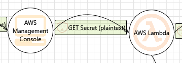

#### 26. AWS Separation of Lambda Concerns [State: Not Started] [Priority: High]

[output not shown]

#### 27. AWS Lambda Low Privilege principle [State: Not Started] [Priority: High]

[output not shown]

#### 28. Encryption in Transit for GET Secret (plaintext) within VPC [State: Not Started] [Priority: High]

| **Category:** | Data Flows |
| --- | --- |
| **Description:** | TLS should be configured for GET Secret (plaintext) to prevent attack related with unauthorized data access within VPC |
| **Justification:** | Security Requirement |
| **Action Items:** | 1. Ensure Strong TLS is configured (TLS 1.2, 1.3) for Decrypted phone number |
| **Comments:** |  |

#### 29. AWS Lambda Enable Dead Letter Queue for Lambda Functions [State: Not Started] [Priority: Low]

| **Category:** | Compute |
| --- | --- |
| **Description:** | Ensure there is a Dead Letter Queue configured for each Lambda function available in your AWS account |
| **Justification:** | <no mitigation provided> |
| **Action Items:** | https://www.trendmicro.com/cloudoneconformity/knowledge-base/aws/Lambda/enable-dead-letter-queue.html |
| **Comments:** |  |

#### 30. Using An IAM Role For More Than One Lambda Function [State: Not Started] [Priority: High]

[output not shown]

#### 31. VPC Access for AWS Lambda Functions [State: Not Started] [Priority: Medium]

[output not shown]

### Interaction: Private Encryption Key

[figure not shown]

#### 32. AWS Separation of Lambda Concerns [State: Not Started] [Priority: High]

[output not shown]

#### 33. AWS Lambda Low Privilege principle [State: Not Started] [Priority: High]

[output not shown]

### Interaction: Store Access Log

[figure not shown]

#### 34. Amazon Macie usage [State: Not Started] [Priority: High]

| **Category:** | Storage |
| --- | --- |
| **Description:** | Usage of Amazon Macie allows to prevent sensitive data (such as PII, access or API keys) leakage and unauthoried access on S3 bucket level |
| **Justification:** | Security Requirement |
| **Action Items:** | 1. Ensure that AWS Amazon Macier is used for AWS S3 scan and its report reviewed on a regular basis |
| **Comments:** |  |

#### 35. AWS Storage encryption [State: Not Started] [Priority: High]

| **Category:** | Storage |
| --- | --- |
| **Description:** | Ensure AWS Storage sensitive information encrypted at Rest to prevent data leakage, unauthorized access or compromise |
| **Justification:** | Security Requirement |
| **Action Items:** | 1. Ensure the sensitive information is encrypted in AWS S3 2. Ensure encryption keys stored in AWS Key Management Service (AWS KMS) |
| **Comments:** |  |

#### 36. Amazon S3 Public Access for AWS Accounts [State: Not Started] [Priority: Medium]

| **Category:** | Storage |
| --- | --- |
| **Description:** | Ensure that Amazon S3 public access is blocked at the AWS account level for data protection. |
| **Justification:** | Security Requirement |
| **Action Items:** | https://www.trendmicro.com/cloudoneconformity/knowledge-base/aws/S3/bucket-public-access-block.html |
| **Comments:** |  |

#### 37. Amazon S3 Public Access for S3 Buckets [State: Not Started] [Priority: Medium]

| **Category:** | Storage |
| --- | --- |
| **Description:** | Ensure that Amazon S3 public access is blocked at the S3 bucket level for data protection |
| **Justification:** | Security Requirement |
| **Action Items:** | https://www.trendmicro.com/cloudoneconformity/knowledge-base/aws/S3/bucket-public-access-block.html |
| **Comments:** |  |

#### 38. S3 Bucket Authenticated Users "FULL_CONTROL,READ,READ_ACP,WRITE,WRITE_ACP" Access [State: Not Started] [Priority: High]

| **Category:** | Storage |
| --- | --- |
| **Description:** | Ensure S3 buckets do not allow FULL_CONTROL access to AWS authenticated users via S3 ACLs or through ACLs |
| **Justification:** | <no mitigation provided> |
| **Action Items:** | https://www.trendmicro.com/cloudoneconformity/knowledge-base/aws/S3/s3-bucket-authenticated-users-full-control-access.html |
| **Comments:** |  |

#### 39. S3 Ensure AWS S3 buckets enforce SSL to secure data in transit [State: Not Started] [Priority: Medium]

| **Category:** | Storage |
| --- | --- |
| **Description:** | Ensure AWS S3 buckets enforce SSL to secure data in transit |
| **Justification:** | <no mitigation provided> |
| **Action Items:** | https://www.trendmicro.com/cloudoneconformity/knowledge-base/aws/S3/secure-transport.html |
| **Comments:** |  |

#### 40. S3 Immutable Objects [State: Not Started] [Priority: Medium]

| **Category:** | Storage |
| --- | --- |
| **Description:** | Ensure that the Objects within the S3 Bucket are Immutable to avoid tempering with the data => each change leads to a fresh version of the S3 Object |
| **Justification:** | <no mitigation provided> |
| **Action Items:** | Enable Object Lock and Versioning |
| **Comments:** |  |

#### 41. S3 Bucket Logging Enabled [State: Not Started] [Priority: Medium]

| **Category:** | Storage |
| --- | --- |
| **Description:** | Ensure AWS S3 buckets have server access logging enabled to track access requests |
| **Justification:** | <no mitigation provided> |
| **Action Items:** | https://www.trendmicro.com/cloudoneconformity/knowledge-base/aws/S3/s3-bucket-logging-enabled.html |
| **Comments:** |  |

#### 42. S3 Bucket MFA Delete Enabled [State: Not Started] [Priority: Low]

| **Category:** | Storage |
| --- | --- |
| **Description:** | Ensure AWS S3 buckets have the MFA Delete feature enabled to avoid unintended deletion of the objects |
| **Justification:** | <no mitigation provided> |
| **Action Items:** | https://www.trendmicro.com/cloudoneconformity/knowledge-base/aws/S3/s3-bucket-mfa-delete-enabled.html |
| **Comments:** |  |

#### 43. Amazon CloudFront Field-Level Encryption [State: Not Started] [Priority: High]

[output not shown]